# Reversing the Stroop Effect

220225579

2023-05-16

## Project Motivation

My aim with the project was to attempt communicating psychological theory in an accessible way. The Stroop Effect was the first lab experiment I ever did in my undergrad Psych course, and it blew my mind. Secondly, having worked with students, it has been my mission to spread the gospel of distributed practice. I hope this assessment will reach more young people (and adults*) and convince them of the wonders of regular learning sessions.

*me

## Data Origins

The data was sourced from *Cognitive Dynamics of a Single Subject: 1428 Stroop Tests and Other Measures in a Mindfulness Meditation Context Over 2.5 Years* by Matti Toivo Juhani Heino (2022), [DOI: 10.5334/jopd.51](https://openpsychologydata.metajnl.com/articles/10.5334/jopd.51).

## Psych 101

### What is the Stroop Effect?

Try saying the *colour* the words are written in (not the word):

**$\color{red}{\text{red}}$**

**$\color{blue}{\text{blue}}$**

**$\color{green}{\text{green}}$**

**$\color{purple}{\text{purple}}$**

That was the **congruent** condition, which is usually simple enough.

Now try that again: say the font colour, not the word:

**$\color{green}{\text{red}}$**

**$\color{red}{\text{blue}}$**

**$\color{purple}{\text{green}}$**

**$\color{blue}{\text{purple}}$**

This condition is called the **incongruent condition** because the colour and word don’t match. Did it take longer this time?

That’s because of the *Stroop Effect*. It’s named after the John Stroop, who realised that it’s faster to say the colour names when the text matches the colour [(Stroop, 1935)](https://psych.hanover.edu/classes/Cognition/papers/stroop%201933.pdf).

But what if there was a way to get better at the Stroop Task?

That brings us to…

### What is distributed practice?

Distributed practice involves short and frequent study sessions over a longer period of time, and it has been shown to improve recalling information [(Cepeda et al, 2006)](http://www.yorku.ca/ncepeda/publications/CPVWR2006.pdf).

This is why teachers don’t like last-minute cram sessions - it doesn’t work in the long term!

## Research Question

What is the effect of distributed practice is on a cognitively difficult undertaking like the Stroop Task?

## Preparing the data

```r
#setting the working directory
setwd("C:/Users/piyal/OneDrive/Desktop/R/psy6422/PSY6422")

#load the relevant libraries
library(tidyverse)
library(here)
library(ggplot2)
```

```r
#load the data
source <- here("data", "cognitive_dynamics_heino.csv")
stroop <- read.csv(source)
```

There are too many variables in the original dataset, so I would like choose the ones relevant for the visualisation.

And also change the names of the columns to make my coding life easier.

```r
#changing column names to make them user/coder friendly
#changing them to make them user/coder friendly
stroop_clean <- stroop %>%
  select(date, stroop_congruent_pre_meditation, stroop_incongruent_pre_meditation) %>%
   rename(congruent = stroop_congruent_pre_meditation,
         incongruent = stroop_incongruent_pre_meditation)

#date is a character, needs to be made into date format
stroop_clean <- stroop_clean %>%
  mutate(date = dmy(date)) %>%                 #changing string to date
  filter(date > "2014-07-01", na.rm = TRUE)    #deleting outliers


#changing centiseconds to milliseconds
stroop_clean <- stroop_clean %>%
  mutate(congruent = congruent * 10,
         incongruent = incongruent * 10)

#reshaping dataframe to long
stroop_long <- stroop_clean %>% select(date, congruent, incongruent) %>%
  gather(condition, time, congruent, incongruent)
```

Let’s have a look at our final dataset!

```r
head(stroop_long)
```

```
##         date condition   time
## 1 2014-07-02 congruent     NA
## 2 2014-07-03 congruent 165.08
## 3 2014-07-04 congruent 110.96
## 4 2014-07-05 congruent 125.58
## 5 2014-07-06 congruent 117.24
## 6 2014-07-07 congruent     NA
```

That looks neat and concise and ready for the next step!

## Visualising the data

I wanted to make a neater visualisation by making some adjustments to the basic ggplot theme.

```r
#defining the theme
theme_stroop <- function(){

  theme_minimal() %+replace%         #replacing the elements I want to change

  theme(

    #grid elements
    panel.grid.minor = element_blank(),

    #text elements
    plot.title = element_text(      #title
      size = 15,                    #set font size
      face = 'bold',                #bold typeface
      hjust = 0,                    #left align
      vjust = 2),                   #raise slightly

    plot.subtitle = element_text(   #subtitle
      size = 10,                    #font size
      hjust = 0),                   #left align

    axis.title = element_text(      #axis titles
      size = 8),                    #font size

    axis.text = element_text(       #axis text
      size = 8),                    #font size

    plot.caption = element_text(    #caption
      size = 8,                     #font size
      hjust = 1),                   #right align

    legend.position = c(.9,.8),  #positioning legend

    plot.background = element_rect(fill = "white", color = NA)
    )
}

#building a colour palette based on the original Stroop colours

palette_stroop <- c("#ff0000", "#0085ff", "#3cff00", "#8c00db", "#543324")
```

A scatter plot with trend lines would give us an idea of the time taken for the each Stroop Task over the years of practice.

Let’s take the first look at our data!

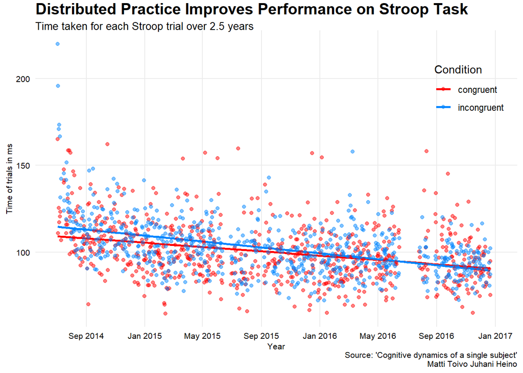

```r
#plotting reaction time for congruent and incongruent trials

#creating the basic plot of time of trials across the years
p1 <- ggplot(data = stroop_long,
             mapping = aes(x = date,
                           y = time,
                           colour = condition))

plot1 <- p1 +
  geom_smooth(method = "lm", se= FALSE)+                                  #drawing the scatter plot
  geom_point(alpha = 0.5) +
  labs(x = "Year",                                                        #labelling the graph
       y = "Time of trials in ms",
       title = "Distributed Practice Improves Performance on Stroop Task",
       subtitle = "Time taken for each Stroop trial over 2.5 years",
       caption = "Source: 'Cognitive dynamics of a single subject'\n Matti Toivo Juhani Heino")+
  theme_stroop() +                                                        #using the theme defined earlier
  scale_colour_manual(values = palette_stroop) +                          #using the colours defined earlier
  scale_x_date(date_breaks = "4 months", date_labels = "%b %Y")+          #defining the breaks on the x-axis
  labs(colour = "Condition")

plot1
```

It looks like practice does make you faster at both tasks - reading the congruent (**$\color{red}{\text{red}}$**) and incongruent (**$\color{blue}{\text{red}}$**) words!

Wait, there’s more! Does deliberate practice actually **reverse the Stroop Effect?!**

Let’s take a closer look.

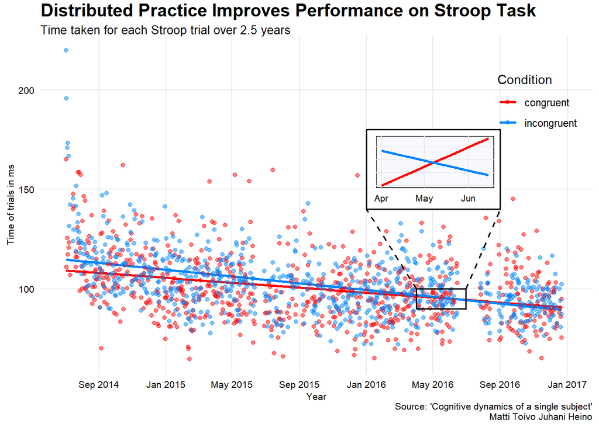

```r
#creating a magnified inset showing crossover

#coordinates of inset
x0 <- as.Date("2016-01-01", "%Y-%m-%d")
x1 <- as.Date("2016-09-01", "%Y-%m-%d")
y0 <- 140
y1 <- 180

#coordinates of origin
x3 <- as.Date("2016-04-01", "%Y-%m-%d")
x4 <- as.Date("2016-06-30", "%Y-%m-%d")
y3 <- 90
y4 <- 100

#coordinates of section to subset
x01 <- as.Date("2016-04-01", "%Y-%m-%d")
x02 <- as.Date("2016-06-15", "%Y-%m-%d")

y01 <- 70
y02 <- 140


#the inset done manually
p2 <- ggplot(data = stroop_long, aes(x = date,                    #basic plot
                                     y = time,
                                     colour = condition)) +
    geom_smooth(method = "lm", se = FALSE, na.rm = TRUE) +        #regression line
  xlim(x01, x02) +                                                #subsetting the part that crosses over
  theme_stroop()+                                                 #use our theme from before
  scale_colour_manual(values = palette_stroop)+                   #using the colours from before
  theme(legend.position = "none") +                               #removing the legend in the inset
  theme(panel.background = element_rect(fill = "ghostwhite"),     #giving it a background to highlight it
        axis.text.y = element_blank(),                            #removing the y-axis text
        axis.title = element_blank())                             #removing the titles from the axes


#adding the inset to the original plot
plot2 <- plot1 +
  annotation_custom(ggplotGrob(p2),    #adding the inset
                    xmin = x0,         #defining the coordinates for the inset
                    xmax = x1,
                    ymin = y0,
                    ymax = y1) +

  geom_rect(aes(xmin = x0,              #border of inset
                xmax = x1,
                ymin = y0,
                ymax = y1),
              colour = "black",
           linewidth = .6,
               alpha = 0) +

  geom_rect(aes(xmin = x3,              #border highlighting the section on graph
                xmax = x4,
                ymin = y3,
                ymax = y4),
              colour = "black",
           linewidth = .6,
                alpha = 0) +

     annotate("segment", x = x3, xend = x0,   #connecting graph to inset
                         y = y4, yend = y0,
             colour = "black",
             linewidth = .6,
             linetype = 2) +
    annotate("segment", x = x4, xend = x1,    #connecting graph to inset
                        y = y4, yend = y0,
           colour = "black",
           linewidth = .6,
           linetype = 2)

plot2
```

```r
#saving our plot
ggsave(here("figs", "stroop_practice_inset.png"),
       plot = plot2, width = 25, height = 15, units = "cm")
```

## Summary

This graph shows the effect of daily practice on the Stroop Effect. With enough practice you could end up reading this incongruent version…

**$\color{green}{\text{red}}$**

**$\color{red}{\text{blue}}$**

**$\color{purple}{\text{green}}$**

**$\color{blue}{\text{purple}}$**

…faster than you read this congruent version:

**$\color{red}{\text{red}}$**

**$\color{blue}{\text{blue}}$**

**$\color{green}{\text{green}}$**

**$\color{purple}{\text{purple}}$**

## Further explorations

- The original dataset also has data on other factors like meditation, the time of day when the Stroop task was done. It would be interesting to see how those additional factors play a role in learning.
- It would also be interesting to see how the Stroop effect changes immediately after a meditation practice. I decided to test the pre-meditation one alone to only see practice effects, and not the effect of meditation.